# Final Project KNN Algorithm

Grant Burden

2023-04-22

Final Project for INFO 523

Source of the Dataset:

```r
'P. W. Frey and D. J. Slate (Machine Learning Vol 6 #2 March 91):
    "Letter Recognition Using Holland-style Adaptive Classifiers".'
```

```
## [1] "P. W. Frey and D. J. Slate (Machine Learning Vol 6 #2 March 91):\n\t\"Letter Recognition Using Holland-style Adaptive Classifiers\"."
```

The code utilizes the tidyverse and caret packages in R.

We load and analyze the initial data set.

```r
#Load the UCi dataset
letters1<- read.csv('./letter-recognition.data', header = FALSE)

#names is citation info--not needed for algorithm


head(letters1)
```

```
##   V1 V2 V3 V4 V5 V6 V7 V8 V9 V10 V11 V12 V13 V14 V15 V16 V17
## 1  T  2  8  3  5  1  8 13  0   6   6  10   8   0   8   0   8
## 2  I  5 12  3  7  2 10  5  5   4  13   3   9   2   8   4  10
## 3  D  4 11  6  8  6 10  6  2   6  10   3   7   3   7   3   9
## 4  N  7 11  6  6  3  5  9  4   6   4   4  10   6  10   2   8
## 5  G  2  1  3  1  1  8  6  6   6   6   5   9   1   7   5  10
## 6  S  4 11  5  8  3  8  8  6   9   5   6   6   0   8   9   7
```

```r
#we have 16 predictors for 26 classes, and 20k observations total
str(letters1)
```

```
## 'data.frame':    20000 obs. of  17 variables:
##  $ V1 : chr  "T" "I" "D" "N" ...
##  $ V2 : int  2 5 4 7 2 4 4 1 2 11 ...
##  $ V3 : int  8 12 11 11 1 11 2 1 2 15 ...
##  $ V4 : int  3 3 6 6 3 5 5 3 4 13 ...
##  $ V5 : int  5 7 8 6 1 8 4 2 4 9 ...
##  $ V6 : int  1 2 6 3 1 3 4 1 2 7 ...
##  $ V7 : int  8 10 10 5 8 8 8 8 10 13 ...
##  $ V8 : int  13 5 6 9 6 8 7 2 6 2 ...
##  $ V9 : int  0 5 2 4 6 6 6 2 2 6 ...
##  $ V10: int  6 4 6 6 6 9 6 2 6 2 ...
##  $ V11: int  6 13 10 4 6 5 7 8 12 12 ...
##  $ V12: int  10 3 3 4 5 6 6 2 4 1 ...
##  $ V13: int  8 9 7 10 9 6 6 8 8 9 ...
##  $ V14: int  0 2 3 6 1 0 2 1 1 8 ...
##  $ V15: int  8 8 7 10 7 8 8 6 6 1 ...
##  $ V16: int  0 4 3 2 5 9 7 2 1 1 ...
##  $ V17: int  8 10 9 8 10 7 10 7 7 8 ...
```

```r
names(letters1)
```

```
##  [1] "V1"  "V2"  "V3"  "V4"  "V5"  "V6"  "V7"  "V8"  "V9"  "V10" "V11" "V12"
## [13] "V13" "V14" "V15" "V16" "V17"
```

```r
#Rename Column Headers and make new data frame:letters2

letters2 <- letters1%>%rename(
 letter  = V1,
  xPos = V2,
  yPos = V3,
  pixWidth = V4,
   pixHeight= V5,
  pixOn = V6,
  xMean = V7,
   yMean= V8,
  xMeanSq = V9,
   yMeanSq= V10,
   XYMean= V11,
  xCorY = V12,
  YCorX = V13,
  edgeMeanHoriz = V14,
   edgeYSum= V15,
   edgeMeanY= V16,
   edgeXSum= V17

)
```

Split into test and Training sets Trying a 70/30 train/test split set seed = 6 for the same splits when creating data partitions

```r
#split into training and test
#Get indices of rows in training set, 70% of rows of letters1,
#set seed keep split consistent

set.seed(6)
indexTrain<- createDataPartition(letters2$xPos, times =1,  p = 0.70, list = FALSE)

#define training set
trainSet <- letters2[indexTrain, ]
#define test set as complement of the test set
testSet <- letters2[-indexTrain, ]
```

Try different values for K–find optimal accuracy and plot it sqrt(n) ~ 140 for the data

```r
knnFit<- train(letter ~., data = trainSet, method ='knn' , tuneGrid = data.frame( k = c(141)))

#multiKnnFit<- knnFit<- train(letter ~., data = trainSet, method ='knn' , tuneGrid = data.frame( k = seq(141, 200,2)))


#view results of knnFit model
#knnFit$results

knnTestPredict<- predict(knnFit, newdata = testSet )

#how accurate did knn predict the letters on the test set?
confMatrixKnn<- confusionMatrix(knnTestPredict, as.factor(testSet$letter))
```

We create visualizations for one run of KNN. We see the accuracy for each individual letter.

```r
#make the results into a df
cm_df<- as.data.frame(confMatrixKnn$byClass)

cm_df
```

```
##          Sensitivity Specificity Pos Pred Value Neg Pred Value Precision
## Class: A   0.9276596   0.9941003      0.8650794      0.9970414 0.8650794
## Class: B   0.8691983   0.9682347      0.5295630      0.9944732 0.5295630
## Class: C   0.7534247   0.9974044      0.9166667      0.9907185 0.9166667
## Class: D   0.8207171   0.9794675      0.6358025      0.9920691 0.6358025
## Class: E   0.6919831   0.9868078      0.6833333      0.9873220 0.6833333
## Class: F   0.8100775   0.9905923      0.7946768      0.9914560 0.7946768
## Class: G   0.7818930   0.9873154      0.7224335      0.9907585 0.7224335
## Class: H   0.5333333   0.9930891      0.7368421      0.9832364 0.7368421
## Class: I   0.7346939   0.9982618      0.9473684      0.9888085 0.9473684
## Class: J   0.8050000   0.9984477      0.9470588      0.9933082 0.9470588
## Class: K   0.5752212   0.9937630      0.7831325      0.9835391 0.7831325
## Class: L   0.8468468   0.9994806      0.9842932      0.9941450 0.9842932
## Class: M   0.8991228   0.9934142      0.8436214      0.9960035 0.8436214
## Class: N   0.7447699   0.9937489      0.8317757      0.9894537 0.8317757
## Class: O   0.8729508   0.9781022      0.6283186      0.9945220 0.6283186
## Class: P   0.7575758   0.9944512      0.8454106      0.9903298 0.8454106
## Class: Q   0.7583333   0.9911428      0.7811159      0.9899393 0.7811159
## Class: R   0.7783019   0.9830626      0.6273764      0.9918047 0.6273764
## Class: S   0.5854701   0.9946218      0.8154762      0.9833619 0.8154762
## Class: T   0.8451883   0.9925334      0.8244898      0.9935686 0.8244898
## Class: U   0.8068670   0.9960104      0.8909953      0.9922240 0.8909953
## Class: V   0.9108911   0.9872326      0.7131783      0.9968641 0.7131783
## Class: W   0.8812785   0.9953279      0.8772727      0.9955002 0.8772727
## Class: X   0.7903226   0.9864348      0.7153285      0.9909154 0.7153285
## Class: Y   0.5236052   0.9963573      0.8531469      0.9810418 0.8531469
## Class: Z   0.8028169   0.9949870      0.8550000      0.9927561 0.8550000
##             Recall        F1 Prevalence Detection Rate Detection Prevalence
## Class: A 0.9276596 0.8952772 0.03917973     0.03634545           0.04201400
## Class: B 0.8691983 0.6581470 0.03951317     0.03434478           0.06485495
## Class: C 0.7534247 0.8270677 0.03651217     0.02750917           0.03001000
## Class: D 0.8207171 0.7165217 0.04184728     0.03434478           0.05401801
## Class: E 0.6919831 0.6876310 0.03951317     0.02734245           0.04001334
## Class: F 0.8100775 0.8023033 0.04301434     0.03484495           0.04384795
## Class: G 0.7818930 0.7509881 0.04051350     0.03167723           0.04384795
## Class: H 0.5333333 0.6187845 0.03501167     0.01867289           0.02534178
## Class: I 0.7346939 0.8275862 0.04084695     0.03001000           0.03167723
## Class: J 0.8050000 0.8702703 0.03334445     0.02684228           0.02834278
## Class: K 0.5752212 0.6632653 0.03767923     0.02167389           0.02767589
## Class: L 0.8468468 0.9104116 0.03701234     0.03134378           0.03184395
```

[output cut: 26 more lines]

```
## Class: L         0.9231637
## Class: M         0.9462685
## Class: N         0.8692594
## Class: O         0.9255265
## Class: P         0.8760135
## Class: Q         0.8747380
## Class: R         0.8806822
## Class: S         0.7900459
## Class: T         0.9188609
## Class: U         0.9014387
## Class: V         0.9490618
## Class: W         0.9383032
## Class: X         0.8883787
## Class: Y         0.7599812
## Class: Z         0.8989020
```

```r
#add column with Letter Classes
letter_col<- LETTERS[seq(from = 1 , to = 26)]
letters_df<- cm_df%>%mutate(Letter_Class = letter_col)

plot_balanced_acc<- letters_df%>%ggplot(aes(x = Letter_Class, y = `Balanced Accuracy` ))+
  geom_point(col = 'darkblue')+
  ggtitle('Balanced Accuracy for Letter Predictions via KNN')+
  xlab('Letter Class')

plot_specificity <- letters_df%>%ggplot(aes(x = Letter_Class, y = Specificity ))+
  geom_point(col = 'darkgreen')+
  ggtitle('Specificity for Letter Predictions via KNN')+
  xlab('Letter Class')


plot_sensitivity <- letters_df%>%ggplot(aes(x = Letter_Class, y = Sensitivity))+
  geom_point(col = 'maroon4')+
  ggtitle('Sensitivity for Letter Predictions via KNN')+
  xlab('Letter Class')
```

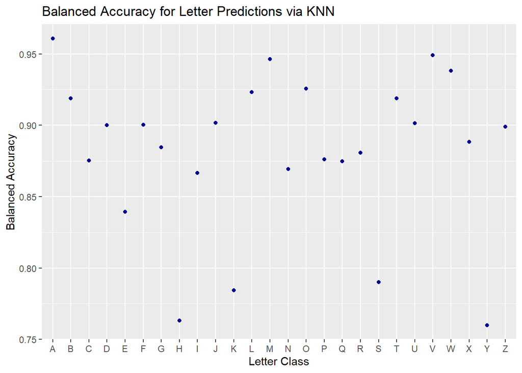

```r
plot(plot_balanced_acc)
```

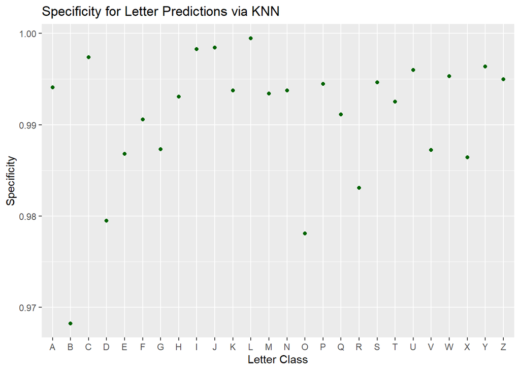

```r
plot(plot_specificity)
```

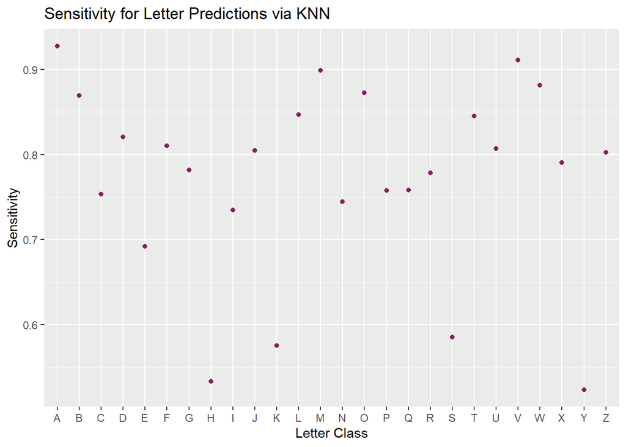

```r
plot(plot_sensitivity)
```

```r
#Model using only edge parameters with K = 141

edgeknnFit<- train(letter ~edgeMeanHoriz+edgeYSum+edgeMeanY+edgeXSum, data = trainSet, method ='knn' , tuneGrid = data.frame( k = c(141)))

# accuracy 0.5226863

edgeknnTestPredict<- predict(edgeknnFit, newdata = testSet )

confusionMatrix(edgeknnTestPredict, as.factor(testSet$letter))
```

```
## Confusion Matrix and Statistics
##
##           Reference
## Prediction   A   B   C   D   E   F   G   H   I   J   K   L   M   N   O   P   Q
##          A 171   0   0   2   0   0   0   1   1   1   2  21   0   1   1   0   1
##          B   0 137   8   1  38   3  29   6   9  12   8  17   2   0   0   7  32
##          C   0   0 101   0  12  10   5   1   6   1   0   1   0   0   0   5   4
##          D   7  11   9  46   1   1   6   1   0   5   4   0   0   3  13   3   7
##          E   0   3   6   0  31   7   7   1   2   0   2   2   0   0   0   4   3
##          F   0   0  15   0   1 125   3   5   3   0   0   2   0   0   0   5   0
##          G   0  15  15   3  13   3 113   1   7   2   1   1   1   0   3   7  42
##          H   3   2  11  23   0   5   1 104   0   0  34   2   1  16  23   0   2
##          I   0   1   0   0   0  24   0   0 175   6   0  61   0   0   0   2   0
##          J   9   0   1   2   2   0   0   0   3 147   0  26   0   0   2   1   0
##          K   3   1   1   5   2   0   7   4   3   0  69   0   0   2   3   1   1
##          L   0   0   0   0   0   0   0   0   1   2   0  55   0   0   0   0   0
##          M   6   0   0   1   0   0   1   0   0   0   2   0 205   6   0   0   0
##          N   2   0   0   6   0   4   0   0   0   0   5   0   7 182   0   1   0
##          O   8   4   3  93   2   3   6  44   0   0  25   0   1   9 123   7  13
##          P   1   0  29   0   1  22   5   5   7   0   5   6   0   1   9 172   3
##          Q   0  14   5   2  21   6   9   2   4   4  23   7   0   0   5   3  71
##          R  13  26   4  12   8   0  35  11   2   0  16   6   2   5   5   1  21
##          S   0   0   2   0   7   2   2   0   6   5   0   1   0   0   0   0   0
##          T   1   1   1   0   5   5   0   0   0   0   0   0   0   0   0   1   0
##          U   0   0   1   1   1   9   0   6   0   0   7   0   0   3   1   0   1
##          V   1   0   1   0   0  15   1   4   0   0   1   0   0   0   0   2   3
##          W   1   0   0   0   0   2   0   0   0   0   3   0   9   6   1   0   0
##          X   2  10   6  49  44   2  12  11  11   6  19   3   0   0  53   2  36
##          Y   2   3   0   2   1   7   1   2   0   1   0   4   0   5   2   7   0
##          Z   5   9   0   3  47   3   0   1   5   8   0   7   0   0   0   0   0
##           Reference
## Prediction   R   S   T   U   V   W   X   Y   Z
##          A   6   4   0   0   0   0   5   0   0
##          B   5  12   1   0   5   4  11   0  15
##          C   0   7   0   0   0   0   0   0   0
##          D   3   2   5   1   2   0  14   1   5
##          E   1   9   4   0   0   0   2   6   0
##          F   0   0  13   0   0   0   9   1   0
##          G   3   9   0   0   1   0   5   0   2
##          H  11   0   1   6   3   9  11   0   0
```

[output cut: 62 more lines]

```
## Pos Pred Value       0.517544  0.62500  0.67965  0.61453  0.84188  0.28372
## Neg Pred Value       0.970258  0.97373  0.98682  0.98419  0.99618  0.97737
## Prevalence           0.039013  0.03985  0.03885  0.03368  0.03651  0.04135
## Detection Rate       0.009837  0.01417  0.02618  0.01834  0.03284  0.02034
## Detection Prevalence 0.019006  0.02267  0.03851  0.02984  0.03901  0.07169
## Balanced Accuracy    0.621297  0.67340  0.83049  0.76632  0.94657  0.71919
##                      Class: Y Class: Z
## Sensitivity           0.67811  0.74178
## Specificity           0.98474  0.96923
## Pos Pred Value        0.64228  0.47024
## Neg Pred Value        0.98696  0.99029
## Prevalence            0.03885  0.03551
## Detection Rate        0.02634  0.02634
## Detection Prevalence  0.04101  0.05602
## Balanced Accuracy     0.83142  0.85551
```

```r
#Training model on mean horizontal and vertical positions, overall width, height and number of 'on' pixels

positionknnFit<- train(letter ~ xPos+
  yPos+
  pixWidth+
   pixHeight+
  pixOn+
  xMean+
   yMean, data = trainSet, method ='knn' , tuneGrid = data.frame( k = c(141)))

PositionknnTestPredict<- predict(positionknnFit, newdata = testSet )
```

```r
set.seed(6)
indexTrainEighty<- createDataPartition(letters2$xPos, times =1,  p = 0.80, list = FALSE)

#define training set
trainSetEighty <- letters2[indexTrainEighty, ]
#define test set as complement of the test set
testSetEighty <- letters2[-indexTrainEighty, ]


knnFitEighty<- train(letter ~., data = trainSetEighty, method ='knn' , tuneGrid = data.frame( k = c(141)))

EightyknnPredict<- predict(knnFitEighty, newdata = testSetEighty)


confusionMatrix(EightyknnPredict, as.factor(testSetEighty$letter))
```

```
## Confusion Matrix and Statistics
##
##           Reference
## Prediction   A   B   C   D   E   F   G   H   I   J   K   L   M   N   O   P   Q
##          A 149   0   0   1   0   0   1   0   0   0   0   4   4   2   1   0   1
##          B   1 135   0   8   8   8   4   9   4   3   1   3   2   1   1   1   4
##          C   0   0 112   0   8   0   0   0   0   0   1   1   0   0   0   0   0
##          D   2   4   0 135   0   3   4   6   7   5   2   0   0  11   4   4   1
##          E   0   0   6   0 101   3   2   0   0   0   9   2   0   0   0   4   1
##          F   0   1   0   1   0 125   0   0   2   0   0   0   0   0   0  14   0
##          G   0   0   7   0   9   0 136   0   3   0   9   5   4   1   3   2   4
##          H   0   0   2   1   0   0   2  80   0   0   8   1   0   1   1   0   0
##          I   0   0   0   0   0   0   0   0 119   7   1   0   0   0   0   0   0
##          J   0   0   0   0   0   0   0   0   6 112   0   0   0   0   0   0   0
##          K   0   0   2   0   1   0   0   5   1   0 105   0   1   0   0   0   0
##          L   0   0   0   1   0   0   0   0   0   1   0 120   0   0   0   0   0
##          M   2   0   0   1   0   0   0   2   0   0   0   0 139   2   0   0   0
##          N   3   0   0   4   0   1   0   4   0   1   1   0   4 127   0   1   0
##          O   0   0   6   9   0   0   2   9   0   4   0   0   1   4 145   1  28
##          P   0   0   0   0   0   8   0   1   0   4   0   0   0   0   0 115   0
##          Q   0   2   0   0   4   0   4   3   0   0   1   0   0   0   2   0 127
##          R   1   5   0   2   3   0   1   8   0   0   9   2   0   2   3   1   1
##          S   0   0   0   1   0   2   0   1   1   2   0   1   0   0   0   0   0
##          T   0   1   1   0   0   7   0   0   1   0   0   0   0   0   0   0   0
##          U   0   0   4   0   3   0   1   1   0   0   7   0   0   1   1   0   0
##          V   0   0   0   0   0   0   0   1   0   0   0   0   0   2   0   1   0
##          W   0   0   0   0   0   1   0   0   0   0   0   0   3   4   5   0   0
##          X   0   0   0   1   4   0   2   0  11   3  12   2   0   0   0   0   0
##          Y   0   0   0   0   0   1   0   2   0   0   0   0   0   0   0   1   0
##          Z   0   0   0   0   6   0   0   0   0   0   0   0   0   0   0   0   0
##           Reference
## Prediction   R   S   T   U   V   W   X   Y   Z
##          A   0   7   0   0   0   0   0   0   0
##          B  25  22   2   0   3   1   0   0   4
##          C   0   0   0   0   0   0   0   0   0
##          D  10   1   0   0   1   0   3   0   0
##          E   1  11   2   0   1   0   6   0   1
##          F   0   3   2   0   0   0   0   2   1
##          G   0   0   1   0   1   1   0   0   0
##          H   2   0   0   2   0   0   0   0   0
```

[output cut: 62 more lines]

```
## Pos Pred Value        0.82500  0.87500  0.85256  0.80503  0.88571  0.74731
## Neg Pred Value        0.98298  0.99426  0.99349  0.99583  0.99663  0.99344
## Prevalence            0.04127  0.04227  0.03952  0.03602  0.03427  0.04102
## Detection Rate        0.02476  0.03677  0.03327  0.03202  0.03102  0.03477
## Detection Prevalence  0.03002  0.04202  0.03902  0.03977  0.03502  0.04652
## Balanced Accuracy     0.79726  0.93217  0.91789  0.94042  0.95048  0.91765
##                      Class: Y Class: Z
## Sensitivity           0.67097  0.83333
## Specificity           0.99740  0.99506
## Pos Pred Value        0.91228  0.86806
## Neg Pred Value        0.98687  0.99351
## Prevalence            0.03877  0.03752
## Detection Rate        0.02601  0.03127
## Detection Prevalence  0.02851  0.03602
## Balanced Accuracy     0.83418  0.91420
```

The below chunk is set not to evaluate. The run time for KNN with K = 101 to 201 is long.

```r
#Most Accurate k

set.seed(6)

indexTrainMax<- createDataPartition(letters2$xPos, times =1,  p = 0.70, list = FALSE)

trainSetMax <- letters2[indexTrainMax, ]
#define test set as complement of the test set
testSetMax <- letters2[-indexTrainMax, ]

knnfitMax<- train(letter ~., data = trainSetMax, method ='knn' , tuneGrid = data.frame( k = c(seq(101, 201, 2))))

#best k was 101 at 78% for 101 to 201

str(knnfitMax)
knnMaxpredict<- predict(knnfitMax, newdata = testSetMax)

confusionMatrix(knnMaxpredict, as.factor(testSetMax$letter) )


knnfitMax$results
```

KNN Model for smaller K:, 5, 7, 9, 11 and 13, using 5 fold cross validation. Optional lines included for tuneGrid of k = 1 to 99 by twos, or k = 1:10.

```r
#Analyze Smaller values of K
#Crossfold Validation
#Also try first 10 default values for K with Tunegrid
#Try Pecific K values 1 to 99 by twos

set.seed(6)

indexTrain2<- createDataPartition(letters2$xPos, times =1,  p = 0.70, list = FALSE)
testSet2<- letters2[-indexTrain2, ]
trainSet2<- letters2[indexTrain2, ]
TRControl<- trainControl(method = 'cv', number = 5)
knnfit2<- train(letter ~., data = trainSet2, method ='knn' , trControl = TRControl, tuneLength = 5)
                #tuneGrid = expand.grid(k = 1:10))
                  #data.frame( k = c(seq(1, 99, 2))))

knnpredict2<- predict(knnfit2, newdata = testSet2)
confusionMatrix(knnpredict2, as.factor(testSet2$letter) )
```

```
## Confusion Matrix and Statistics
##
##           Reference
## Prediction   A   B   C   D   E   F   G   H   I   J   K   L   M   N   O   P   Q
##          A 232   1   0   0   0   0   0   0   0   1   0   0   1   2   0   0   0
##          B   0 221   0   1   2   0   5   2   0   0   2   0   0   1   0   0   0
##          C   0   0 207   0   2   0   0   0   0   0   0   0   0   0   1   0   0
##          D   0   4   0 240   0   0   6   5   0   0   1   0   0   3   4   0   0
##          E   0   2   2   1 220   1   2   1   1   0   3   1   0   0   1   0   0
##          F   0   0   0   0   0 242   0   0   5   2   0   0   0   0   0  13   0
##          G   0   0   2   0   8   0 229   3   0   0   0   2   0   0   1   1   0
##          H   0   2   0   4   0   0   0 179   0   0  12   2   0   2   0   1   0
##          I   0   0   0   0   0   0   0   1 227   8   0   0   0   0   0   0   0
##          J   0   0   0   0   0   1   0   0   9 186   0   1   0   0   0   0   0
##          K   0   0   0   0   1   0   0   5   2   0 198   0   0   0   0   0   0
##          L   0   0   3   0   0   0   0   1   0   1   0 216   0   0   0   0   0
##          M   2   0   0   0   0   0   0   0   0   0   0   0 219   0   0   0   0
##          N   1   0   0   2   0   0   0   0   0   0   0   0   2 224   0   0   0
##          O   0   0   2   2   0   0   0   2   0   0   0   0   0   1 229   0   3
##          P   0   0   0   0   0   9   0   0   0   0   0   0   0   0   0 213   1
##          Q   0   0   0   0   2   0   0   0   1   0   0   0   0   0   7   1 234
##          R   0   4   0   1   0   1   1   7   0   0   3   0   0   5   0   0   1
##          S   0   0   0   0   0   0   0   0   0   2   0   0   0   0   0   0   0
##          T   0   0   3   0   1   3   0   0   0   0   0   0   1   0   0   1   0
##          U   0   0   0   0   0   0   0   1   0   0   0   0   0   0   1   0   0
##          V   0   3   0   0   0   0   0   0   0   0   0   0   2   1   0   0   0
##          W   0   0   0   0   0   1   0   0   0   0   0   0   3   0   0   0   0
##          X   0   0   0   0   1   0   0   1   0   0   7   0   0   0   0   0   0
##          Y   0   0   0   0   0   0   0   2   0   0   0   0   0   0   0   1   1
##          Z   0   0   0   0   0   0   0   0   0   0   0   0   0   0   0   0   0
##           Reference
## Prediction   R   S   T   U   V   W   X   Y   Z
##          A   0   0   0   0   0   0   1   1   0
##          B   6   2   0   0   3   0   0   0   0
##          C   0   0   0   0   0   0   0   0   0
##          D   3   0   0   1   0   0   1   0   0
##          E   0   2   0   0   0   0   4   0   2
##          F   0   1   1   0   0   0   1   0   0
##          G   0   0   0   0   0   0   0   0   0
##          H   2   0   0   2   0   1   0   0   0
```

[output cut: 62 more lines]

```
## Pos Pred Value        0.98246  0.94650  0.98696  0.95652  0.98131  0.94800
## Neg Pred Value        0.99827  0.99844  0.99896  0.99931  0.99844  0.99809
## Prevalence            0.03901  0.03985  0.03885  0.03368  0.03651  0.04135
## Detection Rate        0.03735  0.03835  0.03785  0.03301  0.03501  0.03951
## Detection Prevalence  0.03801  0.04051  0.03835  0.03451  0.03568  0.04168
## Balanced Accuracy     0.97829  0.98004  0.98686  0.98932  0.97911  0.97669
##                      Class: Y Class: Z
## Sensitivity           0.96567  0.97653
## Specificity           0.99844  0.99965
## Pos Pred Value        0.96154  0.99048
## Neg Pred Value        0.99861  0.99914
## Prevalence            0.03885  0.03551
## Detection Rate        0.03751  0.03468
## Detection Prevalence  0.03901  0.03501
## Balanced Accuracy     0.98205  0.98809
```